# Duração de mandato nas Secretarias Estaduais de Saúde

uma análise de como o gênero afeta o tempo dos mandatos nas regiões brasileiras

Alexandra Emanuela Novais Silva

2024-09-04

```r
install.packages("readxl")
install.packages("dplyr")
install.packages("lubridate")
install.packages("ggplot2")
install.packages("tidyr")
install.packages("knitr")
install.packages("broom")
install.packages("rmarkdown")
```

```r
print(secretarios_combinados)
```

```
## # A tibble: 180 × 4
##    Gênero duracao_mandato PARTIDO nome_regiao
##    <chr>            <dbl> <chr>   <chr>
##  1 M                    4 PSDB    Centro-Oeste
##  2 M                    1 DEM     Centro-Oeste
##  3 M                    2 DEM     Centro-Oeste
##  4 M                    2 DEM     Centro-Oeste
##  5 F                    2 PMDB    Centro-Oeste
##  6 M                    4 PT      Centro-Oeste
##  7 M                    1 PT      Centro-Oeste
##  8 M                    1 PT      Centro-Oeste
##  9 F                    1 PT      Centro-Oeste
## 10 M                    2 PT      Centro-Oeste
## # ℹ 170 more rows
```

# Variável de controle

Escolhemos aqui a variável de controle de ideologia dos governadores, isso porque já existe na teoria discussões de que exista relação entre e a indicação de secretarios de saúde e ideologia partidária dos governadores.

```r
 secretarios_combinados <- secretarios_combinados %>%
  mutate(ideologia = case_when(
    PARTIDO %in% c("DEM", "PMDB", "PP", "PSC", "PSD", "PSDB", "SD", "PFL") ~ "Direita",
    PARTIDO %in% c("PCdoB", "PDT", "PSB", "PT", "PPS", "PROS") ~ "Esquerda"))

print(secretarios_combinados)
```

```
## # A tibble: 180 × 5
##    Gênero duracao_mandato PARTIDO nome_regiao  ideologia
##    <chr>            <dbl> <chr>   <chr>        <chr>
##  1 M                    4 PSDB    Centro-Oeste Direita
##  2 M                    1 DEM     Centro-Oeste Direita
##  3 M                    2 DEM     Centro-Oeste Direita
##  4 M                    2 DEM     Centro-Oeste Direita
##  5 F                    2 PMDB    Centro-Oeste Direita
##  6 M                    4 PT      Centro-Oeste Esquerda
##  7 M                    1 PT      Centro-Oeste Esquerda
##  8 M                    1 PT      Centro-Oeste Esquerda
##  9 F                    1 PT      Centro-Oeste Esquerda
## 10 M                    2 PT      Centro-Oeste Esquerda
## # ℹ 170 more rows
```

# Modelo estatístico

O modelo que usamos aqui foi a regressão linear, pois esta é utilizada para verificar se existe significância estatística entre duas variáveis. Para que exista relação então entre os fatores, é necessário que o p valor seja menor que 0.05, isso porque o p valor representa a probabilidade da variável não ser significativa.

# Regressão Linear

```r
modelo_lm <- lm(duracao_mandato ~ Gênero + ideologia, data = secretarios_combinados)

summary(modelo_lm)
```

```
##
## Call:
## lm(formula = duracao_mandato ~ Gênero + ideologia, data = secretarios_combinados)
##
## Residuals:
##     Min      1Q  Median      3Q     Max
## -1.4472 -1.2284 -0.2747  0.7716  5.5991
##
## Coefficients:
##                   Estimate Std. Error t value Pr(>|t|)
## (Intercept)        2.27468    0.29789   7.636 1.37e-12 ***
## GêneroM           -0.04628    0.30028  -0.154    0.878
## ideologiaEsquerda  0.17248    0.23108   0.746    0.456
## ---
## Signif. codes:  0 '***' 0.001 '**' 0.01 '*' 0.05 '.' 0.1 ' ' 1
##
## Residual standard error: 1.485 on 176 degrees of freedom
##   (1 observation deleted due to missingness)
## Multiple R-squared:  0.003545,   Adjusted R-squared:  -0.007779
## F-statistic: 0.313 on 2 and 176 DF,  p-value: 0.7316
```

Desse modo, demostramos que o resutado da regressão os dados não são siginificantes estatisitcamente para explicar nossa hipótese da influencia de gênero na duração dos mandatos nas secretarias de estaduais de saúde.

#Resultados

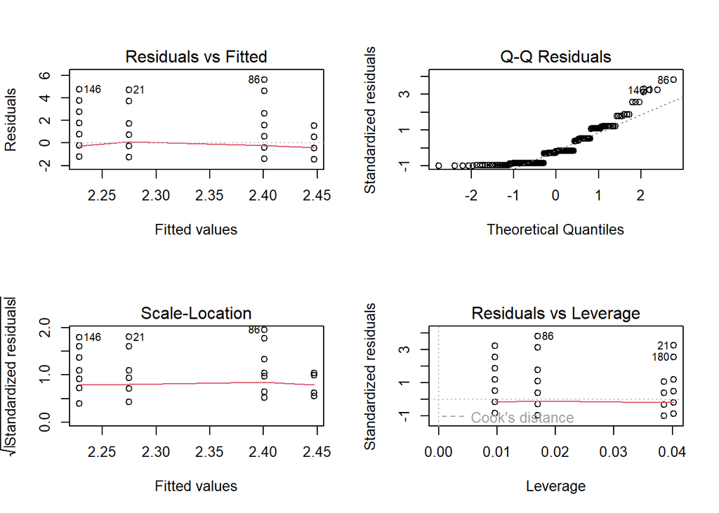

```r
par(mfrow=c(2,2))
plot(modelo_lm)
```

```r
par(mfrow=c(1,1))
```

Além disso, os gráficos da análise de pressupostos, que demonstram primeiro que, há linearidade mas não a homocedasticidade. Verificamos também que distribuição não é normal. Além disso, que há pontos de alavancagem e que na nossa amostra existem outliers.

# Conclusão

Apesar da literatura apresentar a dificuldade de mulheres ascenderem e permanecerem em cargos de liderança, nossos dados demonstraram que não existe relação entre as variáveis de análise, o gênero e a duração de mandato. Apesar de inserimos uma variável de idelogia como controle, nós não obtivemos significância estatística para a correlação. Isso pode indicar que nossa hipótese é rasa ou mesmo que existe a necessidade de indicarmos outras variáveis para que o teste seja mais robusto.